# Client Report - Using Machine Learning to Predict Which Houses are Old

- Show All Code
- Hide All Code

Course DS 250

Author

Spencer Hepworth

## Safety for your family:

*Using this model will be essential for promoting the safety of individuals, especially when working with data that the year of the house built is unavailable. This is essential for those who might be sentitive to materials used to be built in older homes, and those who was to exercise an abundance of caution towards materials such as lead paint and aspestous.*

*We were able to build a reliable model with 95.9% accuracy. It uses the random tree classifier to analyze the data to make predictions about which houses were built before 1980. Parting out the parcel data was an important step in getting the last few increments of accuracy. Live area was another important piece in detecting old houses.*

```python
# Securely fetch the data using requests and certifi
url1 = 'https://github.com/byuidatascience/data4dwellings/raw/master/data-raw/dwellings_denver/dwellings_denver.csv'
url2 = 'https://raw.githubusercontent.com/byuidatascience/data4dwellings/master/data-raw/dwellings_ml/dwellings_ml.csv'

response1 = requests.get(url1, verify=certifi.where())
response2 = requests.get(url2, verify=certifi.where())

# Check if the request was successful
if response1.status_code == 200:
    # Read the content of the response into a pandas DataFrame
    denver_data = pd.read_csv(io.StringIO(response1.content.decode('utf-8')))
    # Print the first 5 rows of the data
else:
    print("Failed to retrieve data: Status code", response1.status_code)
if response2.status_code == 200:
    # Read the content of the response into a pandas DataFrame
    ml_data = pd.read_csv(io.StringIO(response2.content.decode('utf-8')))
    # Print the first 5 rows of the data
else:
    print("Failed to retrieve data: Status code", response2.status_code)

variable_description = {
    'parcel': 'Character: The parcel id',
    'abstrprd': 'Numeric: No clue',
    'livearea': 'Numeric: Square footage that is liveable',
    'finbsmnt': 'Numeric: Square footage finished in the basement',
    'basement': 'Numeric: Total square footage of the basement',
    'yrbuilt': 'Numeric: Year the home was built',
    'totunits': 'Numeric: How many dwelling units in the building',
    'stories': 'Numeric: The number of stories',
    'nocars': 'Numeric: Size of the garage in cars',
    'numbdrm': 'Numeric: Number of bedrooms',
    'numbaths': 'Numeric: Number of bathrooms',
    'sprice': 'Numeric: Selling price',
    'deduct': 'Numeric: Deduction from the selling price',
    'netprice': 'Numeric: Net price of home',
    'tasp': 'Numeric: Tax assessed selling price',
    'smonth': 'Numeric: Month sold',
    'syear': 'Numeric: Year sold',
    'condition_AVG': 'Numeric: 0 or 1 to mark building having attribute as 1',
    'condition_Excel': 'Numeric: 0 or 1 to mark building having attribute as 1',
    'condition_Fair': 'Numeric: 0 or 1 to mark building having attribute as 1',
    'condition_Good': 'Numeric: 0 or 1 to mark building having attribute as 1',
    'condition_VGood': 'Numeric: 0 or 1 to mark building having attribute as 1',
    'quality_A': 'Numeric: 0 or 1 to mark building having attribute as 1',
    'quality_B': 'Numeric: 0 or 1 to mark building having attribute as 1',
    'quality_C': 'Numeric: 0 or 1 to mark building having attribute as 1',
    'quality_D': 'Numeric: 0 or 1 to mark building having attribute as 1',
    'quality_X': 'Numeric: 0 or 1 to mark building having attribute as 1',
    'gartype_Att': 'Numeric: 0 or 1 to mark building having attribute as 1',
    'gartype_Att/Det': 'Numeric: 0 or 1 to mark building having attribute as 1',
    'gartype_CP': 'Numeric: 0 or 1 to mark building having attribute as 1',
    'gartype_Det': 'Numeric: 0 or 1 to mark building having attribute as 1',
    'gartype_None': 'Numeric: 0 or 1 to mark building having attribute as 1',
    'gartype_att/CP': 'Numeric: 0 or 1 to mark building having attribute as 1',
    'gartype_det/CP': 'Numeric: 0 or 1 to mark building having attribute as 1',
    'arcstyle_BI-LEVEL': 'Numeric: 0 or 1 to mark building having attribute as 1',
    'arcstyle_CONVERSIONS': 'Numeric: 0 or 1 to mark building having attribute as 1',
    'arcstyle_END UNIT': 'Numeric: 0 or 1 to mark building having attribute as 1',
    'arcstyle_MIDDLE UNIT': 'Numeric: 0 or 1 to mark building having attribute as 1',
    'arcstyle_ONE AND HALF-STORY': 'Numeric: 0 or 1 to mark building having attribute as 1',
    'arcstyle_ONE-STORY': 'Numeric: 0 or 1 to mark building having attribute as 1',
    'arcstyle_SPLIT LEVEL': 'Numeric: 0 or 1 to mark building having attribute as 1',
    'arcstyle_THREE-STORY': 'Numeric: 0 or 1 to mark building having attribute as 1',
    'arcstyle_TRI-LEVEL': 'Numeric: 0 or 1 to mark building having attribute as 1',
    'arcstyle_TRI-LEVEL WITH BASEMENT': 'Numeric: 0 or 1 to mark building having attribute as 1',
    'arcstyle_TWO AND HALF-STORY': 'Numeric: 0 or 1 to mark building having attribute as 1',
    'arcstyle_TWO-STORY': 'Numeric: 0 or 1 to mark building having attribute as 1',
    'qualified_Q': 'Numeric: 0 or 1 to mark building having attribute as 1',
    'qualified_U': 'Numeric: 0 or 1 to mark building having attribute as 1',
    'status_I': 'Numeric: 0 or 1 to mark building having attribute as 1',
    'status_V': 'Numeric: 0 or 1 to mark building having attribute as 1',
    'before1980': 'Numeric: 0 or 1 to mark building having attribute as 1',
    'book_num': 'Numeric: The first part of the parcel id',
    'page_num': 'Numeric: The second part of the parcel number',
    'parcel_num': 'Numeric: The part of the parcel number related to their portion of land',
    'unit_num': 'Numeric: The part of the parcel related to the unit number.'
}
```

**Here we will explore the relationship between homes built before 1980 and different aspects of our data. This will help us discover what metrics will be useful for our model.**

## Graph: Live area and year built:

*Here we see the live area density of homes built before 1980 peaks in a different area as compared to homes built after 1980*

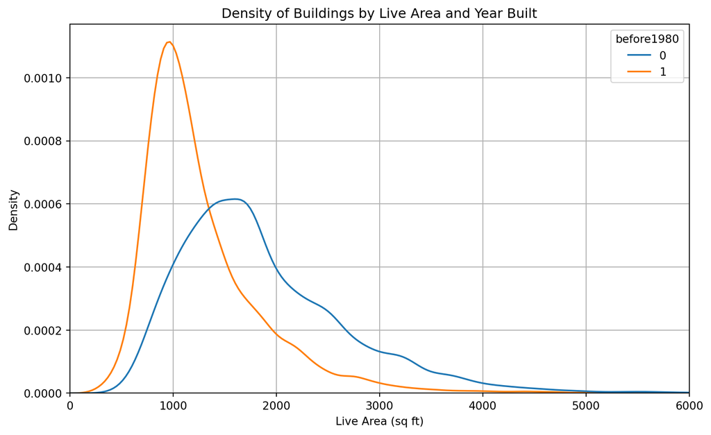

```python
livearea_range = (0, 6000)
plt.figure(figsize=(10, 6))
sns.kdeplot(
    data=ml_data,
    x='livearea',
    hue='before1980',
    common_norm=False,
    clip=livearea_range
)
plt.title('Density of Buildings by Live Area and Year Built')
plt.xlabel('Live Area (sq ft)')
plt.ylabel('Density')
plt.xlim(livearea_range)  # Limit the x-axis to the range of interest
plt.grid(True)
plt.show()
```

## Graph: Heatmap for the correlation between parcel data and year built

*We discover that there is a strong correlation between parcel number and parcel units.*

**the heatmap of our data**

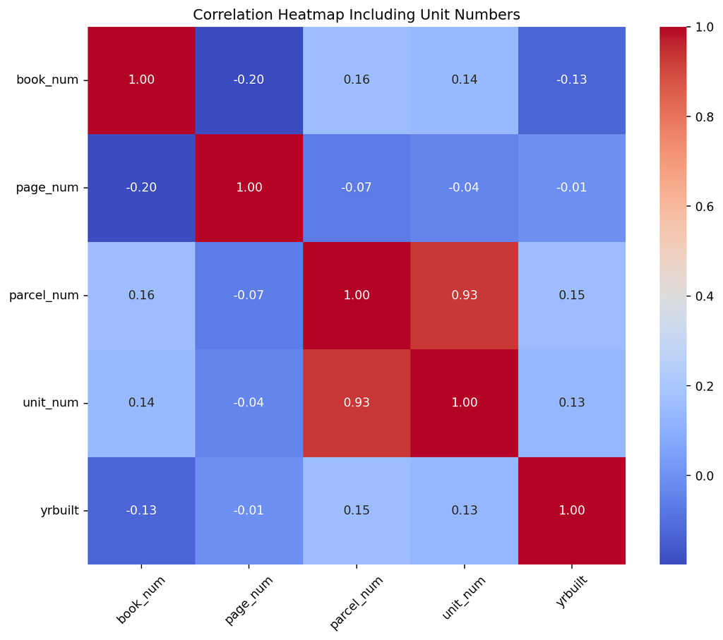

```python
dwellings_ml = ml_data.copy()

# Split the 'parcel' column into separate parts and expand into separate columns
parcel_parts = dwellings_ml['parcel'].str.split('-', expand=True)

dwellings_ml['book_num'] = pd.to_numeric(dwellings_ml['parcel'].str.split('-', expand=True)[0], errors='coerce')
dwellings_ml['page_num'] = pd.to_numeric(dwellings_ml['parcel'].str.split('-', expand=True)[1], errors='coerce')
dwellings_ml['parcel_num'] = pd.to_numeric(dwellings_ml['parcel'].str.split('-', expand=True)[2], errors='coerce')
dwellings_ml['unit_num'] = pd.to_numeric(dwellings_ml['parcel'].str.split('-', expand=True)[3], errors='coerce')


dwellings_ml['parcel_unit_interaction'] = pd.to_numeric(dwellings_ml['parcel_num'] * dwellings_ml['unit_num'], errors='coerce')


features_to_correlate = ['book_num', 'page_num', 'parcel_num', 'unit_num', 'yrbuilt']
correlation_matrix = dwellings_ml[features_to_correlate].corr()

# Plotting the heatmap
plt.figure(figsize=(10, 8))
sns.heatmap(correlation_matrix, annot=True, fmt=".2f", cmap='coolwarm', cbar=True, square=True)
plt.title('Correlation Heatmap Including Unit Numbers')
plt.xticks(rotation=45)
plt.yticks(rotation=0)
plt.show()
```

## The best man for the job: Random Forest Classifier

*Included for the model are all rows of data. We let the program decide which data is significant and which data isn’t. In addition, we turned the parcel number into more useful pieces of data. I chose this model because I ran code to simultaneously test all the models, and this is the one with the best results.*

```python
X = dwellings_ml.drop(columns=['yrbuilt', 'before1980', 'parcel'])
y = dwellings_ml['before1980']

X = pd.get_dummies(X, drop_first=True)

X_train, X_test, y_train, y_test = train_test_split(X, y, test_size=0.2, random_state=42)


# Best parameters found by GridSearchCV
best_params = {'max_depth': None,
               'min_samples_leaf': 1,
               'min_samples_split': 5,
               'n_estimators': 200}

# Initialize the RandomForestClassifier with the best parameters
rfc_optimized = RandomForestClassifier(max_depth=best_params['max_depth'],
    min_samples_leaf=best_params['min_samples_leaf'],
    min_samples_split=best_params['min_samples_split'],
    n_estimators=best_params['n_estimators'],
    random_state=42)  # It's good practice to set a random_state for reproducibility

# Now, you can fit this model to your training data
rfc_optimized.fit(X_train, y_train)

# And make predictions or evaluate its performance
y_pred = rfc_optimized.predict(X_test)

# Evaluate the model

test_accuracy = accuracy_score(y_test, y_pred)
print(f"Test set accuracy with optimized parameters: {test_accuracy:.4f}")
```

```
Test set accuracy with optimized parameters: 0.9594
```

*Book number appears to be the most important determiner when learning whether a house was built before 1980.*

```python
feature_importances = rfc_optimized.feature_importances_
importance_df = pd.DataFrame({'Feature': X_train.columns, 'Importance': feature_importances})

# Merge importance_df with variable_description
importance_df = importance_df.merge(pd.DataFrame.from_dict(variable_description, orient='index', columns=['Description']),
    left_on='Feature', right_index=True, how='left')

# Sort the DataFrame by importance values in descending order
importance_df = importance_df.sort_values(by='Importance', ascending=False)

top_n = 10  # You can adjust this value to print more or fewer features
print("Top {} most important features:".format(top_n))
print(tabulate(importance_df.head(top_n), headers='keys', tablefmt='fancy_grid'))
```

```
Top 10 most important features:
╒════╤════════════════════╤══════════════╤═════════════════════════════════════════════════════════════════════════╕
│    │ Feature            │   Importance │ Description                                                             │
╞════╪════════════════════╪══════════════╪═════════════════════════════════════════════════════════════════════════╡
│ 48 │ book_num           │    0.171594  │ Numeric: The first part of the parcel id                                │
├────┼────────────────────┼──────────────┼─────────────────────────────────────────────────────────────────────────┤
│ 37 │ arcstyle_ONE-STORY │    0.0673221 │ Numeric: 0 or 1 to mark building having attribute as 1                  │
├────┼────────────────────┼──────────────┼─────────────────────────────────────────────────────────────────────────┤
│  5 │ stories            │    0.0585926 │ Numeric: The number of stories                                          │
├────┼────────────────────┼──────────────┼─────────────────────────────────────────────────────────────────────────┤
│  1 │ livearea           │    0.0565069 │ Numeric: Square footage that is liveable                                │
├────┼────────────────────┼──────────────┼─────────────────────────────────────────────────────────────────────────┤
│  8 │ numbaths           │    0.0503972 │ Numeric: Number of bathrooms                                            │
├────┼────────────────────┼──────────────┼─────────────────────────────────────────────────────────────────────────┤
│ 22 │ quality_C          │    0.0472272 │ Numeric: 0 or 1 to mark building having attribute as 1                  │
├────┼────────────────────┼──────────────┼─────────────────────────────────────────────────────────────────────────┤
│ 25 │ gartype_Att        │    0.0438935 │ Numeric: 0 or 1 to mark building having attribute as 1                  │
├────┼────────────────────┼──────────────┼─────────────────────────────────────────────────────────────────────────┤
│ 12 │ tasp               │    0.0372386 │ Numeric: Tax assessed selling price                                     │
├────┼────────────────────┼──────────────┼─────────────────────────────────────────────────────────────────────────┤
│ 50 │ parcel_num         │    0.0361268 │ Numeric: The part of the parcel number related to their portion of land │
├────┼────────────────────┼──────────────┼─────────────────────────────────────────────────────────────────────────┤
│  9 │ sprice             │    0.0327785 │ Numeric: Selling price                                                  │
╘════╧════════════════════╧══════════════╧═════════════════════════════════════════════════════════════════════════╛
```

## Justification of metrics:

*Precision: Imagine you’re trying to guess which houses were built before 1980. Precision is like being precise with your guesses. If your precision is high, it means most of the houses you guessed were built before 1980 are actually correct. So, if you say, “I think this house was built before 1980,” you’re usually right.*

*Recall: Recall is like not missing any houses that were actually built before 1980. If your recall is high, it means you’re good at spotting all the houses that were built before 1980. So, you don’t miss many old houses when you’re guessing which ones are old.*

*F1 Score: The F1 score combines both precision and recall. It’s like looking at both how often you’re right with your guesses and how many old houses you manage to find. A high F1 score means you’re both accurate with your guesses and you don’t miss many old houses. It’s like hitting a sweet spot between being right and not missing anything.*

```python
## Calculate the precision
precision = precision_score(y_test, y_pred)

# Calculate the recall
recall = recall_score(y_test, y_pred)

# Calculate the F1 score
f1 = f1_score(y_test, y_pred)

# Print the evaluation metrics
print("Precision:", round(precision, 4))
print("Recall:", round(recall, 4))
print("F1 Score:", round(f1, 4))
```

```
Precision: 0.9663
Recall: 0.969
F1 Score: 0.9677
```

Back to top